# Taller 1 Simulación

2022-03-15

##### Presentado por : Cristian Flórez Nieto & Juan Miguel Giraldo Zuluaga

## Punto 1

Al comparar los caracteres morfométricos de una especie de langostinos de gran importancia económica en Argentina se observaron diferencias de tamaño entre macho y hembra. En la siguiente tabla se presentan los datos (Largo total mm) de las morfometrías de machos y hembras obtenidos en diferentes recolectas (Ruiz & Mendia, 2008).

1. Haga un histograma con cinco clases y determine la distribución de los datos para cada sexo. Explique acerca de la distribución del tamaño para cada género.

RESPUESTA:

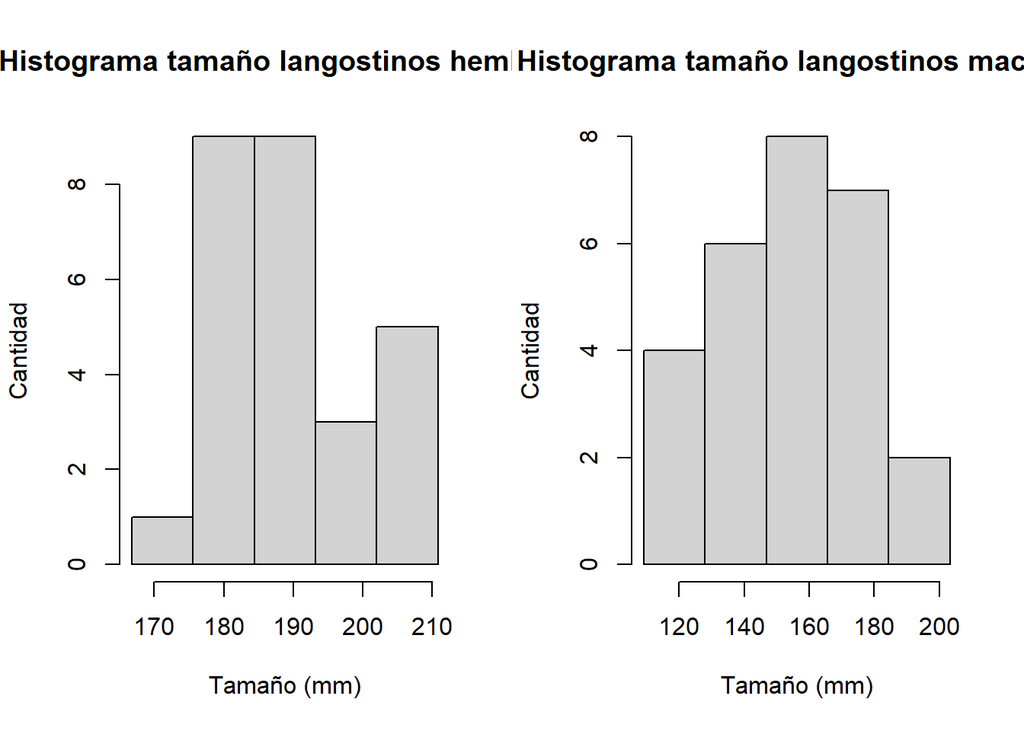

[output not shown]

2. Hallar el promedio y la desviación estándar para cada sexo. ¿Qué puede concluir?

RESPUESTA:

```
## La media de los machos es:  154.4667 , y su desviación estandar es:  23.06462
```

```
## La media de las hembras es:  189.0667 , y su desviación estandar es:  9.831151
```

```
## INTERPRETACIÓN: De esto podemos concluir que en promedio los langostinos hembra son mas grandes que los machos, además de que la desviación estandar de las hembras es menor lo que nos indica que varia menos el tamaño en hembras que en machos.
```

3. Halle un intervalo para la media del Largo total por sexo con un nivel de confianza del 97%. Provea la interpretación respectiva.

RESPUESTA:

```
## El valor inferior del intervalo de confianza de la media de las hembras es: 185.3205 .
## El valor superior del intervalo de confianza de la media de las hembras es: 192.8128
```

```
## El valor inferior del intervalo de confianza de la media de los machos es: 145.6779 .
## El valor superior del intervalo de confianza de la media de los machos es: 163.2555
```

```
## INTERPRETACIÓN: Con base en el intervalo para la media que se calcularon podemos inferir que con un 97% de confianza la media real de la poblacion es para machos entre [145.677 - 163.255] y para hembras [185.32 - 192.812]
```

4. Construya un Boxplot por sexo e interpretelo.

RESPUESTA:

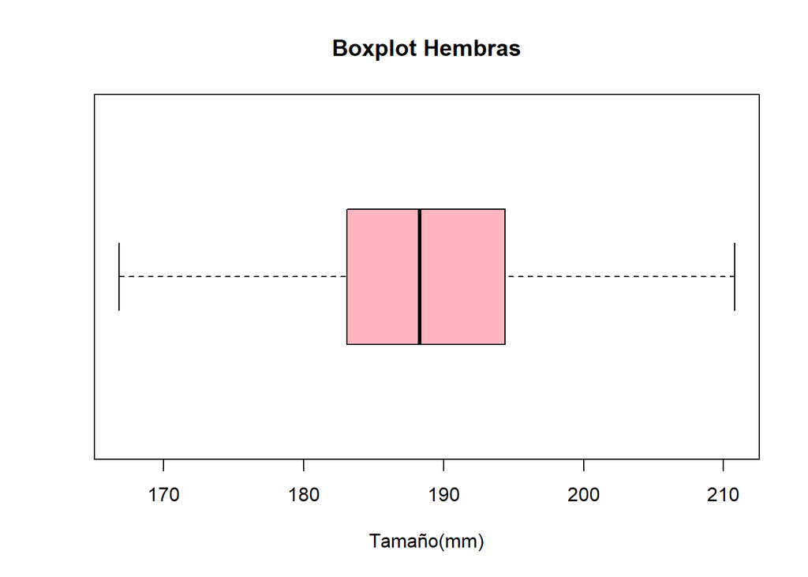

```
## INTERPRETACION: La aglomeración de los datos se repesenta gracias al tamaño de la caja y la media está más cercana al cuartil 1
```

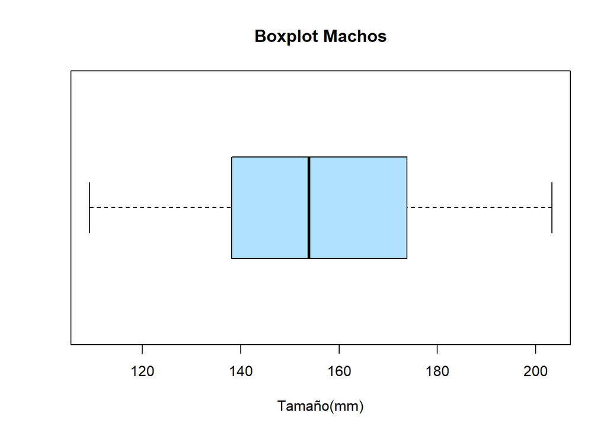

```
## INTERPRETACION: No hay tanta concentración de datos, es decir, están más dispersos y que la media es más cercana al cuartil 1
```

5. Comprobar la normalidad de los datos.

RESPUESTA:

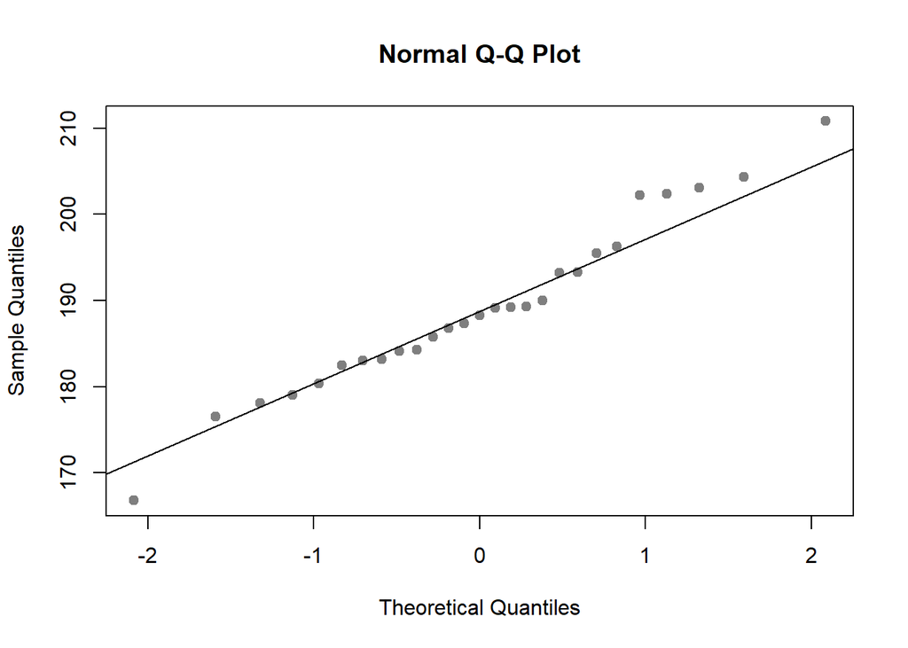

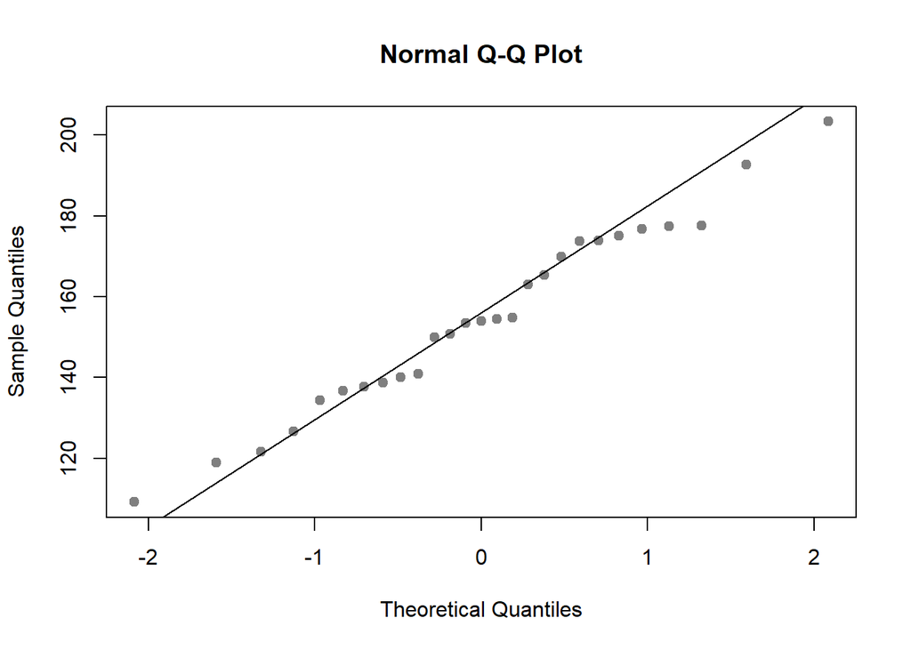

## Punto 2

En un restaurante de la ciudad se sabe que la probabilidad de que se reciba un billete de $50.000 falso es de 0.015. Si se sabe que en una semana se reciben pagos con 900 billetes de $50.000, halle la probabilidad de que:

1. A lo sumo 25 billetes sean falsos.

RESPUESTA:

```
## La probabildiad de que a los sumo 25 billetes sean falsos es:  0.9985199
```

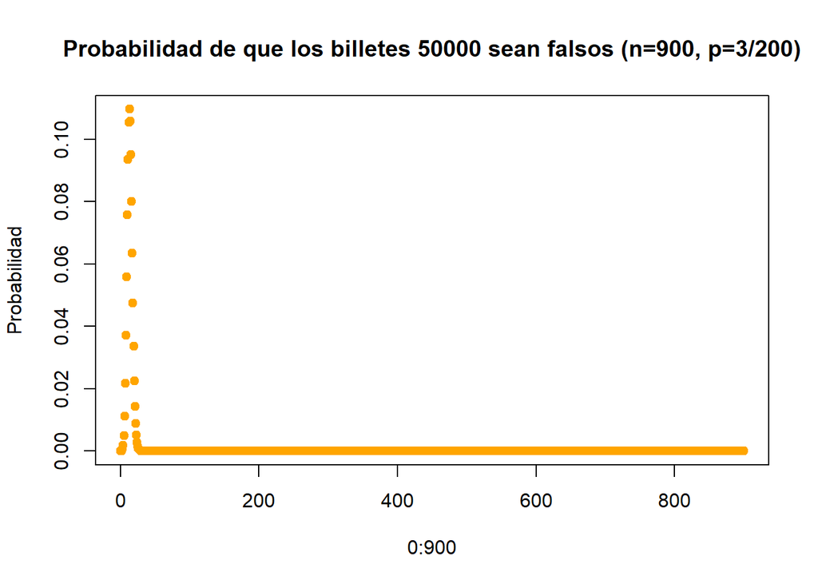

2. La cantidad de billetes falsos esté entre 20 y 30.

RESPUESTA:

```
## La probabilidad de que la cantidad de billetes falsos está entre 20 y 30 es:  0.03395327
```

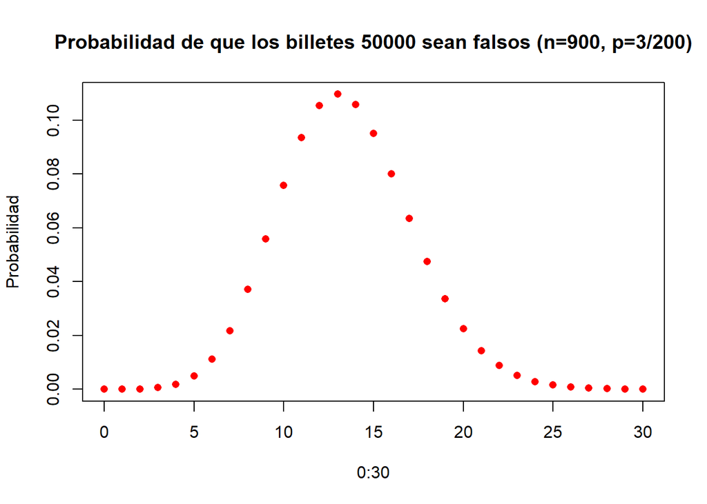

3. Más de 10 sean falsos.

RESPUESTA:

```
## La probabilidad de que mas de 10 billetes sean falsos es:  0.7907816
```

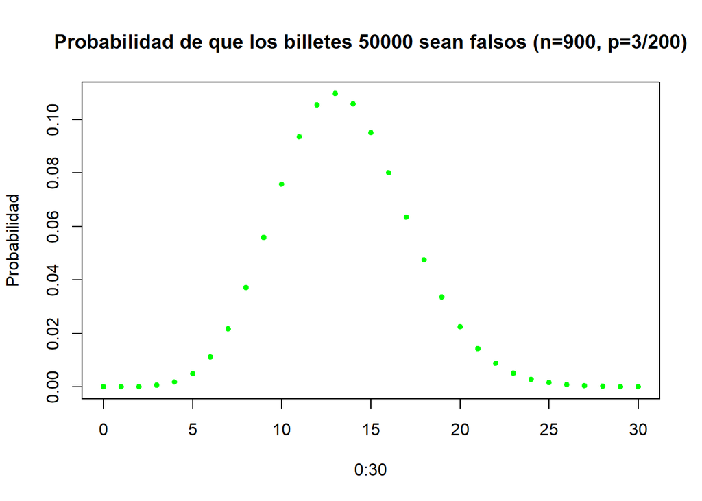

## Punto 3

Según un estudio del Departamento Nacional de Estadística -DANE-, la vida media para el quinquenio de 2010 a 2015 de los habitantes de Colombia es 76 años, con una varianza de 25. Se pretende hacer un estudio con el objetivo de extrapolar los resultados anteriores a una pequeña ciudad de 100.000 habitantes, considerando que el tiempo de sobrevida es normal.

1. ¿Cuántos de los habitantes de la pequeña ciudad superarán previsiblemente los 92 años?

RESPUESTA:

```
## La probabilidad de que personas que viviran mas de 92 años es:  0.0006871379
```

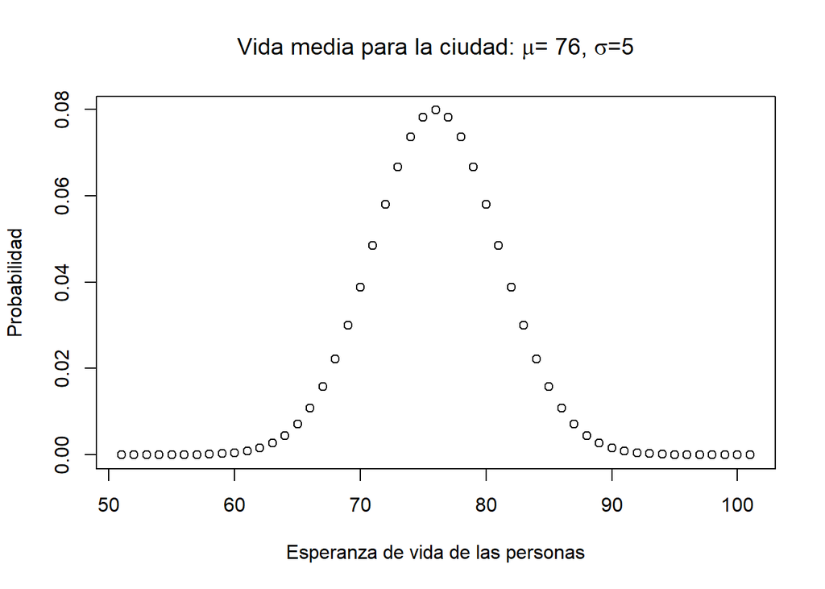

2. ¿Cuántos vivirán menos de 55 años o más de 75 años?

RESPUESTA:

```
## La probabilidad de que personas que viviran menos de 55 o mas de 75 años es:  0.5792731
```

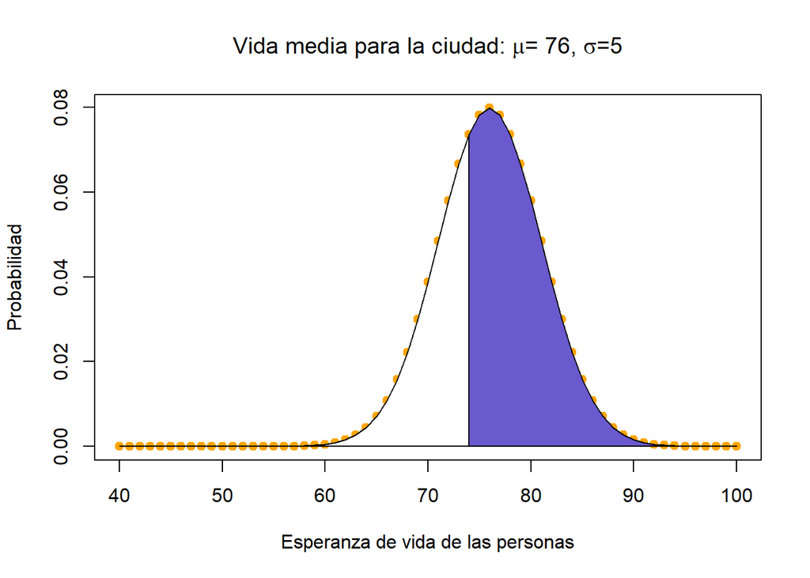